# Caki-1 Transcriptome or Gene expression

2026-03-22

### Introduction

**Project Background and Objectives.** Hypoxia is a hallmark of the microenvironment in many solid human tumors, driving significant transcriptomic alterations. Two primary models are employed to simulate these conditions:

- Physiological Hypoxia: Culturing cells in a specialized low-oxygen incubator.
- Chemical Mimicry: Treatment with Cobalt Chloride (CoCl<sub>2</sub>), which chemically stabilizes HIF-1 alpha.

This study involves a re-analysis of RNA-seq data from human Caki-1 cells (clear cell renal cell carcinoma) to evaluate the transcriptomic fidelity of CoCl<sub>2</sub> as a hypoxia mimetic.

**Data Source.** The raw transcriptomic data used in this analysis were retrieved from the NCBI BioProject database via the recount2 accession number SRP066934.

### Setup and Data import

```r
# Library imports
library(tidyverse)
library(DESeq2)
library(EnsDb.Hsapiens.v86)
library(EnhancedVolcano)
library(dplyr)
library(ggplot2)
library(ggplotify)
library(pheatmap)
library(apeglm)
library(msigdbr)
library(ggpubr)
library(clusterProfiler)
library(enrichplot)
library(DT)
library(patchwork)

# Read and inspect the dataset
load("rse_gene.Rdata")
rse <- rse_gene
mapping <- data.frame(
  run = c(
    "SRR2970559",
    "SRR2970560",
    "SRR2970562",
    "SRR2970566",
    "SRR2970569",
    "SRR2970570",
    "SRR2970573",
    "SRR2970575",
    "SRR2970578"
  ),
  cond = c(rep("Untreated", 3), rep("CoCl2", 3), rep("Hypoxia", 3))
)
rse$condition <- factor(rep(c("Untreated", "CoCl2", "Hypoxia"), each = 3),
  levels = c("Untreated", "Hypoxia", "CoCl2")
)
as.data.frame(colData(rse)[, c("run", "condition")])
# make the gene names readable for annotation
rownames(rse) <- gsub(pattern = "\\..+", replacement = "", x = rownames(rse))
all(assay(rse) == floor(assay(rse))) # check if counts are integers
all(rownames(colData(rse)) == colnames(assay(rse))) # check if the metadata match count matrix
colData(rse) <- colData(rse)[, c("sample", "run", "condition")] # select data for analysis
rse$condition <- relevel(rse$condition, ref = "Untreated") # assign the control factor explicitly
```

The detailed sample information was retrieved from the SRA database using the corresponding accession numbers. Samples were categorized into three groups and the “Untreated” state (cells cultured under standard atmospheric O<sub>2</sub> levels without chemical additives) was formally assigned as the baseline for all differential expression comparisons.

### Exploratory Data Analysis

To ensure reliable analysis, raw counts were normalized using Variance Stabilizing Transformation (VST). This minimizes the impact of sequencing depth differences and stabilizes variance across the dataset.

#### PCA Plot

The PCA plot visualizes the global transcriptomic relationships between samples:

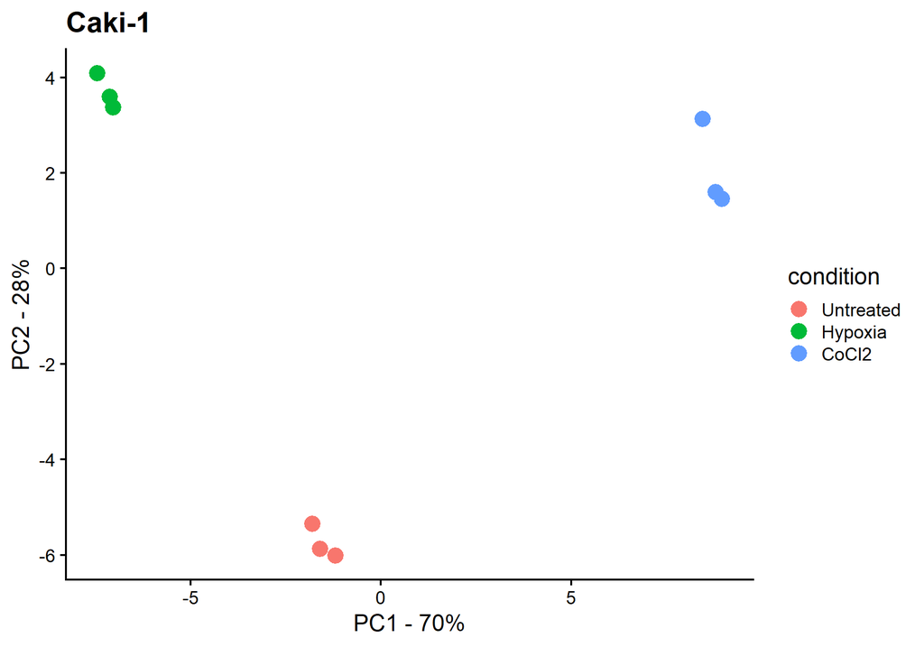

```r
# Normalization
dds <- DESeqDataSet(rse, design = ~condition)
keep <- rowSums(counts(dds)) >= 10
dds <- dds[keep, ]
vsd <- vst(dds, blind = FALSE)

# PCA
pcaData <- plotPCA(vsd, intgroup = "condition", returnData = TRUE)
percentVar <- round(100 * attr(pcaData, "percentVar"))

ggplot(pcaData, aes(x = PC1, y = PC2, color = condition, label = name)) +
  geom_point(size = 5) +
  xlab(paste0("PC1 - ", percentVar[1], "%")) +
  ylab(paste0("PC2 - ", percentVar[2], "%")) +
  theme_classic(base_size = 18) +
  ggtitle("Caki-1") +
  theme(plot.title = element_text(size = 22, face = "bold"))
```

#### MA Plot

The MA plots visualize the scale of transcriptomic shifts:

- Lots of genes are significantly affected in both models.
- CoCl<sub>2</sub> treatment triggers a higher number of upregulated genes and more extreme fold-changes than real hypoxia.
- Although the CoCl<sub>2</sub> response is “stronger” in magnitude, this increased intensity suggests the activation of additional stress pathways beyond standard hypoxia signaling.

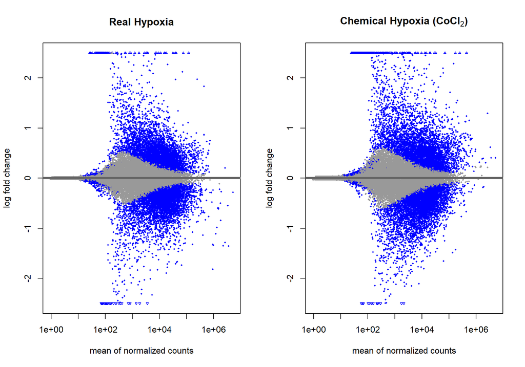

```r
dds <- DESeq(dds)
res_real_hypoxia <- results(dds, contrast = c("condition", "Hypoxia", "Untreated"))
resNorm_real_hypoxia <- lfcShrink(
  dds = dds,
  coef = "condition_Hypoxia_vs_Untreated",
  type = "apeglm"
)

res_chemical_hypoxia <- results(dds, contrast = c("condition", "CoCl2", "Untreated"))
resNorm_chemical_hypoxia <- lfcShrink(
  dds = dds,
  coef = "condition_CoCl2_vs_Untreated",
  type = "apeglm"
)
par(mfrow = c(1, 2))
common_ylim <- c(-2.5, 2.5)
plotMA(resNorm_real_hypoxia, main = "Real Hypoxia", ylim = common_ylim)
plotMA(resNorm_chemical_hypoxia, main = bquote(bold("Chemical Hypoxia (" * CoCl[2] * ")")), ylim = common_ylim)
```

```r
par(mfrow = c(1, 1))
```

### Differentially expressed genes

#### Volcano plot

The Volcano plot provides a global overview of the relationship between statistical significance (-log<sub>10</sub> P<sub>adj</sub>) and the magnitude of change (log<sub>2</sub> Fold Change).

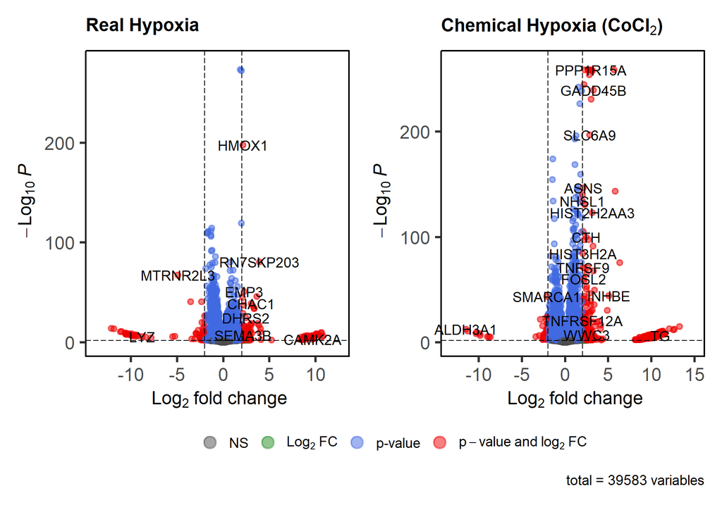

```r
# Global settings
p_adj_cut <- 0.01
lfc_cut <- 1
base_mean_cut <- 20

# Annotation
ens2sym <- AnnotationDbi::select(EnsDb.Hsapiens.v86,
  keys = keys(EnsDb.Hsapiens.v86),
  columns = c("SYMBOL")
)

resdf_real_hypoxia <- as.data.frame(resNorm_real_hypoxia) |>
  rownames_to_column() |>
  mutate(GENEID = gsub(rowname, pattern = "\\..+", replacement = "")) |>
  dplyr::select(-rowname) |>
  inner_join(y = ens2sym, by = "GENEID")

resdf_chemical_hypoxia <- as.data.frame(resNorm_chemical_hypoxia) |>
  rownames_to_column() |>
  mutate(GENEID = gsub(rowname, pattern = "\\..+", replacement = "")) |>
  dplyr::select(-rowname) |>
  inner_join(y = ens2sym, by = "GENEID")

p1 <- EnhancedVolcano(resdf_real_hypoxia,
  lab = resdf_real_hypoxia$SYMBOL,
  x = "log2FoldChange", y = "padj",
  pCutoff = p_adj_cut, FCcutoff = 2,
  title = "Real Hypoxia",
  subtitle = NULL,
  caption = NULL,
  gridlines.major = FALSE, gridlines.minor = FALSE,
  border = "full",
  legendPosition = "none"
)

# Chemical Hypoxia
p2 <- EnhancedVolcano(resdf_chemical_hypoxia,
  lab = resdf_chemical_hypoxia$SYMBOL,
  x = "log2FoldChange", y = "padj",
  pCutoff = p_adj_cut, FCcutoff = 2,
  title = bquote(bold("Chemical Hypoxia (" * CoCl[2] * ")")),
  subtitle = NULL,
  gridlines.major = FALSE, gridlines.minor = FALSE,
  border = "full"
)

# Join with one legend
(p1 | p2) +
  plot_layout(guides = "collect") &
  theme(legend.position = "bottom")
```

- Real Hypoxia shows a focused and physiological response. HMOX1 (Heme Oxygenase 1), a classic marker of oxygen deprivation and antioxidant defense, is among the most significantly upregulated genes.
- Chemical Hypoxia (CoCl<sub>2</sub>) exhibits a much more intense and “crowded” profile. The top-ranked genes, such as PPP1R15A and GADD45B, are primarily associated with DNA damage and growth arrest. CoCl<sub>2</sub> treatment reaches substantially higher levels of statistical significance, indicating a more aggressive and potentially toxic cellular impact compared to real hypoxia.
- The divergence in top-labeled genes confirms that while both conditions trigger transcriptomic shifts, they do so through different primary mechanisms.

#### Top Significant DEGs

```r
sig_res_real <- resdf_real_hypoxia |>
  filter(padj < p_adj_cut & abs(log2FoldChange) >= lfc_cut & baseMean >= base_mean_cut)

sig_res_chemical <- resdf_chemical_hypoxia |>
  filter(padj < p_adj_cut & abs(log2FoldChange) >= lfc_cut & baseMean >= base_mean_cut)

# find top DEGs for both conditions
top_real_names <- sig_res_real |>
  arrange(padj) |>
  head(20) |>
  pull(SYMBOL)
top_chem_names <- sig_res_chemical |>
  arrange(padj) |>
  head(20) |>
  pull(SYMBOL)

# find common unique top DEGs
all_top_genes <- unique(c(top_real_names, top_chem_names))

# join the top genes into common table to compare
comparison_table <- resdf_real_hypoxia |>
  filter(SYMBOL %in% all_top_genes) |>
  dplyr::select(SYMBOL, LFC_Real = log2FoldChange, padj_Real = padj) |>
  inner_join(
    resdf_chemical_hypoxia |> dplyr::select(SYMBOL, LFC_Chem = log2FoldChange, padj_Chem = padj),
    by = "SYMBOL"
  )

# display one table
datatable(comparison_table,
  colnames = c("Gene Symbol", "LFC Real Hypoxia", "padj Real hypoxia", "LFC Chemical hypoxia", "padj Chemical hypoxia"),
  rownames = FALSE,
  options = list(
    pageLength = 10,
    scrollX = TRUE
  )
) |>
  formatRound(columns = c("LFC_Real", "LFC_Chem"), digits = 3) |>
  formatSignif(columns = c("padj_Real", "padj_Chem"), digits = 3) |>
  # Додає кольорові бари прямо в комірки LFC
  formatStyle(c("LFC_Real", "LFC_Chem"),
    backgroundColor = styleInterval(0, c("#B8F4FF", "#FFB8B8"))
  )
```

| Gene Symbol | LFC Real Hypoxia | padj Real hypoxia | LFC Chemical hypoxia | padj Chemical hypoxia |
| --- | --- | --- | --- | --- |
| HIPK2 | -1.228605615717314 | 2.801675736946441e-115 | -0.5526660791257235 | 9.315198011639373e-25 |
| PPP1R15A | 0.4168029431461281 | 4.24790082541977e-10 | 2.963692162962639 | 0 |
| FTL | 0.8268789921701244 | 1.395812633544551e-59 | 2.287184236762962 | 0 |
| CBX5 | -1.207270354199222 | 5.158484901053371e-93 | 0.5654032913507512 | 3.206121108288876e-21 |
| GADD45B | 1.478707664572898 | 1.243154185266e-48 | 3.273296621436981 | 7.399031855797091e-240 |
| HMOX1 | 2.119745963218542 | 2.901835400921657e-198 | 5.697947404843361 | 0 |
| RPL3 | 0.2502138271280943 | 9.686866872146953e-10 | 1.152832714529799 | 1.344831556738509e-193 |
| SLC7A5 | 0.3794448662409958 | 3.489854263613692e-15 | 1.547676685378534 | 7.140183114563558e-243 |
| TLE4 | -1.169967032893555 | 2.887771127568074e-80 | -0.2402911944304224 | 0.0003221496054432347 |
| STC2 | 0.4511982989443796 | 4.763290298168982e-11 | 2.730648923899996 | 0 |

[output cut: 27 more lines]

To evaluate the overlap between the two models, the top 20 most significant genes (P<sub>adj</sub>) from each condition were cross-referenced. This resulted in a combined list of 37 unique genes, indicating a remarkably low overlap of only 3 shared genes among the top candidates. - The minimal overlap in top DEGs suggests that while both treatments are potent, they activate largely divergent primary transcriptomic programs. - The magnitude (log<sub>2</sub> FC) and the direction of change (indicated by color) often differs significantly, with CoCl<sub>2</sub> typically inducing more extreme shifts.

#### Expression Heatmap

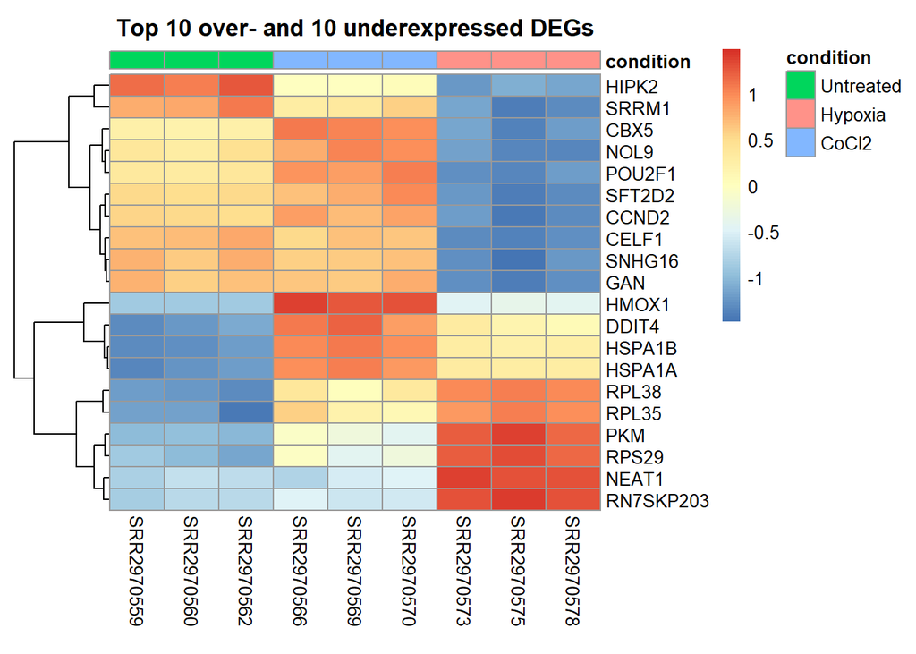

```r
# Choose the significant genes by major contrast (real hypoxia)
sig_res <- resdf_real_hypoxia |>
  filter(padj < p_adj_cut & baseMean >= base_mean_cut)

sig_ordered <- sig_res |> arrange(padj)
# Selecting the top 10 over- and under-expressed DEGs prioritized by statistical significance
# (lowest padj) to ensure robust expression patterns across replicates.
top_10_over <- sig_ordered |>
  filter(log2FoldChange > 0) |>
  head(10)

top_10_under <- sig_ordered |>
  filter(log2FoldChange < 0) |>
  head(10)

# Combine over- and underexpressed genes
hm_genes_id <- c(top_10_over$GENEID, top_10_under$GENEID)
hm_genes_symbols <- c(top_10_over$SYMBOL, top_10_under$SYMBOL)

# Prepare the matrix
mat_final <- assay(vsd)[hm_genes_id, ]
rownames(mat_final) <- hm_genes_symbols


pheatmap(mat_final,
  scale = "row",
  cluster_cols = FALSE,
  annotation_col = as.data.frame(colData(vsd)[, "condition", drop = FALSE]),
  main = "Top 10 over- and 10 underexpressed DEGs",
  cellwidth = 30,
  cellheight = 12
)
```

Heatmap reveals two primary gene blocks: a top cluster of genes downregulated in physical hypoxia and a bottom cluster of genes upregulated across both treatment groups. While CoCl<sub>2</sub> effectively induces common hypoxia markers like HMOX1 and DDIT4, it fails to replicate the gene repression (blue areas) observed in the physical hypoxia samples. Stress-related genes (HSPA1A/B) show significantly higher expression levels (darker red) in the CoCl<sub>2</sub> group compared to the physical hypoxia group.

### GSEA: Significantly enriched pathways

#### Table

```r
# load KEGG pathways
kegg_sets <- msigdbr(species = "Homo sapiens", category = "C2", subcategory = "CP:KEGG_LEGACY") |>
  dplyr::select(gs_name, gene_symbol)

# Rank
ranks_real <- as.data.frame(res_real_hypoxia) |>
  rownames_to_column("GENEID") |>
  mutate(GENEID = gsub(GENEID, pattern = "\\..+", replacement = "")) |>
  inner_join(ens2sym, by = "GENEID") |>
  filter(!is.na(stat) & !is.na(SYMBOL)) |>
  distinct(SYMBOL, .keep_all = TRUE) |>
  arrange(desc(stat)) |>
  dplyr::select(SYMBOL, stat) |>
  deframe()

ranks_chem <- as.data.frame(res_chemical_hypoxia) |>
  rownames_to_column("GENEID") |>
  mutate(GENEID = gsub(GENEID, pattern = "\\..+", replacement = "")) |>
  inner_join(ens2sym, by = "GENEID") |>
  filter(!is.na(stat) & !is.na(SYMBOL)) |>
  distinct(SYMBOL, .keep_all = TRUE) |>
  arrange(desc(stat)) |>
  dplyr::select(SYMBOL, stat) |>
  deframe()

# Launch GSEA
gsea_real <- GSEA(ranks_real, TERM2GENE = kegg_sets, pvalueCutoff = 1, verbose = FALSE)
gsea_chem <- GSEA(ranks_chem, TERM2GENE = kegg_sets, pvalueCutoff = 1, verbose = FALSE)

# Combine into one interactive table by 'Condition'
gsea_combined <- bind_rows(
  as.data.frame(gsea_real) |> mutate(Condition = "Real hypoxia"),
  as.data.frame(gsea_chem) |> mutate(Condition = "Chemical hypoxia")
)

top_combined_clean <- gsea_combined |>
  group_by(Condition) |>
  slice_min(order_by = p.adjust, n = 5, with_ties = FALSE) |>
  ungroup() |>
  dplyr::select(Condition, Description, everything(), -ID, -core_enrichment, -leading_edge)

datatable(top_combined_clean,
  filter = "top",
  rownames = FALSE,
  options = list(
    pageLength = 10,
    scrollX = TRUE,
    autoWidth = TRUE,
    columnDefs = list(
      list(className = "dt-nowrap", targets = "_all"),
      list(width = "300px", targets = 1)
    )
  ),
  caption = "Top 5 KEGG Pathways per Condition"
) |>
  formatRound(columns = c("enrichmentScore", "NES"), digits = 3) |>
  formatSignif(columns = c("pvalue", "p.adjust", "qvalue"), digits = 3)
```

| Condition | Description | setSize | enrichmentScore | NES | pvalue | p.adjust | qvalue | rank |
| --- | --- | --- | --- | --- | --- | --- | --- | --- |
| Chemical hypoxia | KEGG_RIBOSOME | 88 | 0.91364032147902 | 3.043467998108271 | 1e-10 | 1.83e-08 | 1.126315789473684e-08 | 1508 |
| Chemical hypoxia | KEGG_ALZHEIMERS_DISEASE | 145 | -0.5690274791715297 | -2.147205603272517 | 1.38450610919821e-09 | 1.266823089916362e-07 | 7.796955457063605e-08 | 4580 |
| Chemical hypoxia | KEGG_OOCYTE_MEIOSIS | 108 | -0.5951595574317969 | -2.135101497455954 | 9.965151027667177e-09 | 6.078742126876978e-07 | 3.741302315650484e-07 | 6003 |
| Chemical hypoxia | KEGG_PROPANOATE_METABOLISM | 32 | -0.7793985776233092 | -2.267330158027111 | 5.540248729404112e-08 | 2.534663793702381e-06 | 1.560017405384842e-06 | 3432 |
| Chemical hypoxia | KEGG_VALINE_LEUCINE_AND_ISOLEUCINE_DEGRADATION | 42 | -0.7249714605498514 | -2.230168353652024 | 1.749541239506532e-07 | 6.403320936593906e-06 | 3.941071844783135e-06 | 6842 |
| Real hypoxia | KEGG_RIBOSOME | 88 | 0.818811136573228 | 2.980036594110656 | 1e-10 | 1.83e-08 | 1.126315789473684e-08 | 2536 |
| Real hypoxia | KEGG_WNT_SIGNALING_PATHWAY | 145 | -0.5889007295146205 | -2.106396803405996 | 1.318962784069281e-09 | 1.206850947423392e-07 | 7.427843047127006e-08 | 4899 |
| Real hypoxia | KEGG_GLYCOLYSIS_GLUCONEOGENESIS | 56 | 0.700796170677513 | 2.34059557504062 | 5.362020883258432e-09 | 3.270832738787643e-07 | 2.013109594767201e-07 | 3585 |
| Real hypoxia | KEGG_PATHWAYS_IN_CANCER | 312 | -0.4525367527218564 | -1.779482335304435 | 9.638898211163151e-08 | 4.409795931607142e-06 | 2.714110812090677e-06 | 4899 |
| Real hypoxia | KEGG_ANTIGEN_PROCESSING_AND_PRESENTATION | 63 | 0.634805971541525 | 2.163112478509023 | 3.701925259375689e-07 | 1.354904644931502e-05 | 8.339073742172605e-06 | 6641 |

#### Plot

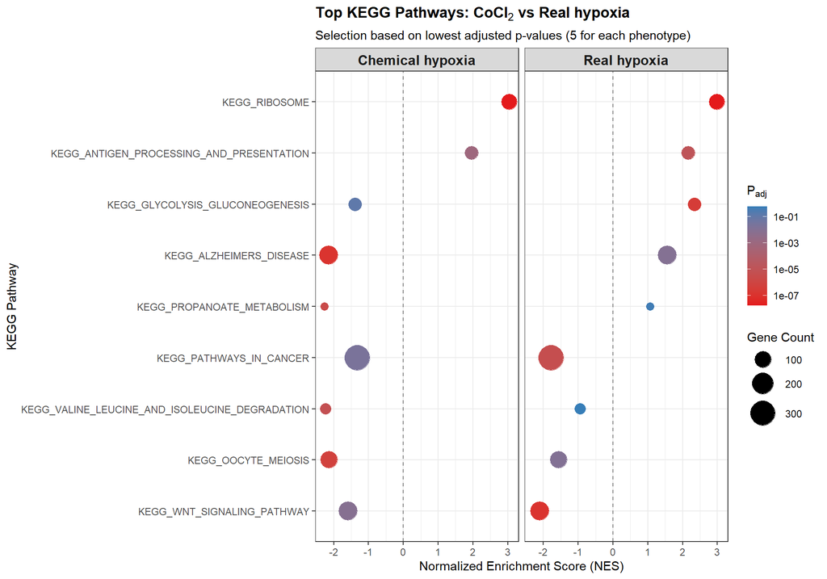

```r
# Data for the plot - TOP 5 by lowest p.adjust
top_paths <- gsea_combined |>
  group_by(Condition) |>
  # Вибираємо топ-5 саме за значущістю (p.adjust)
  slice_min(order_by = p.adjust, n = 5, with_ties = FALSE) |>
  pull(ID) |>
  unique()

gsea_plot_df <- gsea_combined |>
  filter(ID %in% top_paths) |>
  mutate(
    NES = as.numeric(NES),
    p.adjust = as.numeric(p.adjust),
    Count = as.numeric(setSize)
  )

# Тепер малюємо ggplot
ggplot(gsea_plot_df, aes(x = NES, y = reorder(Description, NES))) +
  geom_point(aes(size = Count, color = p.adjust)) +
  scale_color_gradient(
    low = "#e41a1c", high = "#377eb8",
    name = expression(P[adj]),
    trans = "log10",
    breaks = c(1e-7, 1e-5, 1e-3, 1e-1)
  ) +
  scale_size_continuous(name = "Gene Count", range = c(3, 10)) +
  facet_grid(. ~ Condition) +
  geom_vline(xintercept = 0, linetype = "dashed", color = "gray50") +
  theme_bw() +
  theme(strip.text = element_text(size = 12, face = "bold")) +
  labs(
    title = bquote(bold("Top KEGG Pathways: " * CoCl[2] * " vs Real hypoxia ")),
    subtitle = "Selection based on lowest adjusted p-values (5 for each phenotype)",
    x = "Normalized Enrichment Score (NES)",
    y = "KEGG Pathway"
  )
```

While broad categories such as various neurodegenerative disease signatures (e.g., Alzheimer’s) and cancer pathways showed high statistical significance, they were not prioritized for detailed analysis. Their enrichment is likely attributed to extensive gene overlap with core mitochondrial respiration and general survival signaling. Instead, the focus was directed toward more granular metabolic and stress-response pathways, which provide a clearer distinction between the physiological hypoxia and chemical stress phenotypes.

### Commons and differences between significantly enriched pathways

#### Ribosome

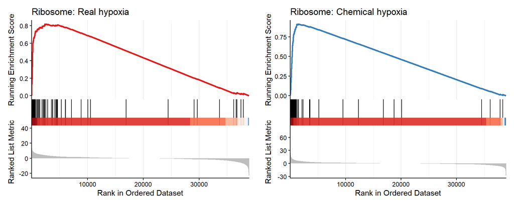

```r
p1_a <- gseaplot2(gsea_real, geneSetID = "KEGG_RIBOSOME", title = "Ribosome: Real hypoxia", color = "#E41A1C")
p1_b <- gseaplot2(gsea_chem, geneSetID = "KEGG_RIBOSOME", title = "Ribosome: Chemical hypoxia", color = "#377EB8")
panel_ribo <- ggarrange(as.ggplot(p1_a), as.ggplot(p1_b), ncol = 2)
plot_ribo <- ggarrange(panel_ribo, nrow = 1)

print(plot_ribo)
```

Both conditions exhibited a robust and nearly identical enrichment of the KEGG_RIBOSOME pathway. This indicates a shared cellular strategy to manage stress by modulating protein synthesis and translational machinery.

#### Glycolysis and propanoate metabolism

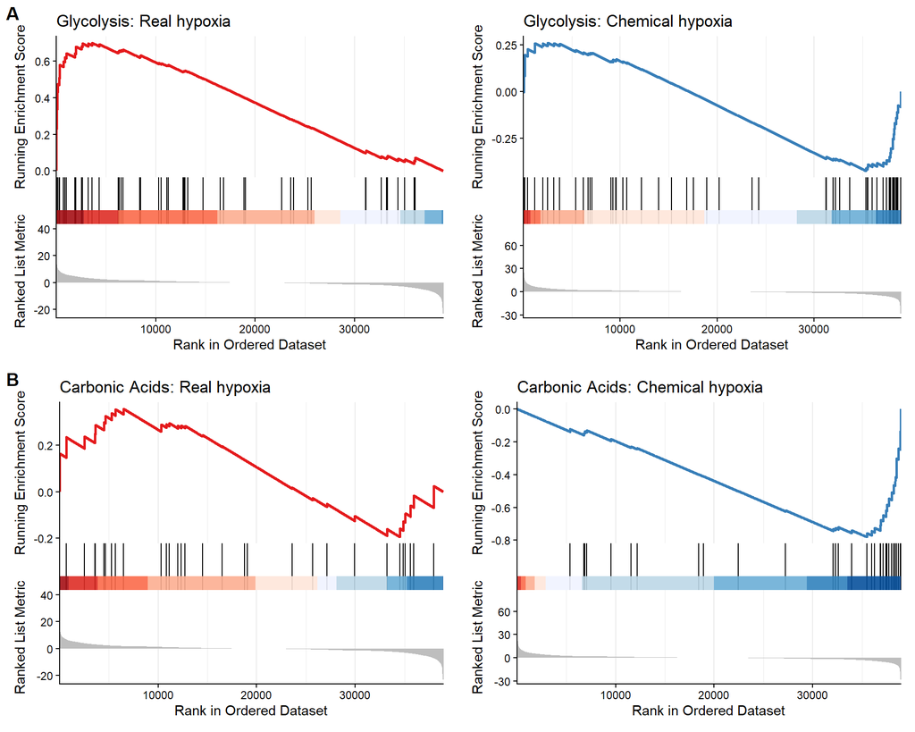

```r
p2_a <- gseaplot2(gsea_real, geneSetID = "KEGG_GLYCOLYSIS_GLUCONEOGENESIS", title = "Glycolysis: Real hypoxia", color = "#E41A1C")
p2_b <- gseaplot2(gsea_chem, geneSetID = "KEGG_GLYCOLYSIS_GLUCONEOGENESIS", title = "Glycolysis: Chemical hypoxia", color = "#377EB8")
panel_glyc <- ggarrange(as.ggplot(p2_a), as.ggplot(p2_b), ncol = 2)

p3_a <- gseaplot2(gsea_real, geneSetID = "KEGG_PROPANOATE_METABOLISM", title = "Carbonic Acids: Real hypoxia", color = "#E41A1C")
p3_b <- gseaplot2(gsea_chem, geneSetID = "KEGG_PROPANOATE_METABOLISM", title = "Carbonic Acids: Chemical hypoxia", color = "#377EB8")
panel_carb <- ggarrange(as.ggplot(p3_a), as.ggplot(p3_b), ncol = 2)

plot_glyc_carb <- ggarrange(panel_glyc, panel_carb,
  nrow = 2, labels = c("A", "B")
)

print(plot_glyc_carb)
```

Glycolysis serves as the primary energy source when oxidative phosphorylation is compromised, while Propanoate metabolism provides essential carbon skeletons for the TCA cycle and gluconeogenesis. Their activation is a hallmark of the “hypoxic switch” required for cell survival.

#### Amino Acids metabolism

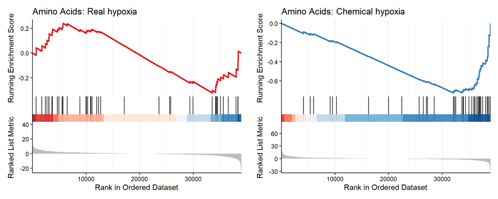

```r
p4_a <- gseaplot2(gsea_real, geneSetID = "KEGG_VALINE_LEUCINE_AND_ISOLEUCINE_DEGRADATION", title = "Amino Acids: Real hypoxia", color = "#E41A1C")
p4_b <- gseaplot2(gsea_chem, geneSetID = "KEGG_VALINE_LEUCINE_AND_ISOLEUCINE_DEGRADATION", title = "Amino Acids: Chemical hypoxia", color = "#377EB8")
panel_amino <- ggarrange(as.ggplot(p4_a), as.ggplot(p4_b), ncol = 2)

plot_amino <- ggarrange(panel_amino, nrow = 1)

print(plot_amino)
```

CoCl<sub>2</sub> treatment specifically induced alterations in the KEGG_VALINE_LEUCINE_AND_ISOLEUCINE_DEGRADATION pathway, which remained unaffected in real hypoxia. This enrichment likely reflects a secondary “chemical footprint” related to metal-induced toxicity rather than hypoxic signaling.